# ONLINE CRYPTOGRAPHY COURSE

VICTOR NYARIBO

5/19/2021

## a) Data Analytic Question

The aim of this project is to identify individuals most likely to click on an online cryptography course advert.

## c) Context

Internet has become the most prominent and accessible way to spread the news about an event or to pitch, advertise and sell a product, globally. The success of any advertisement campaign lies in reaching the right class of target audience and eventually convert them as potential customers in the future. Businesses are predominantly charged based the number of clicks that they received for their advertisement while some websites also bill them with a fixed charge per billing cycle. This creates a necessity for the advertising firms to analyze and study these influential factors to achieve the maximum possible gain through the advertisements. Additionally, it is equally important for the businesses to customize these factors rightly to achieve the maximum clicks.

## d) Data Understanding

Variables

- Daily Time Spent on a Site: Time spent by the user on a site in minutes.
- Age:Customer’s age in terms of years.
- Area Income: Average income of geographical area of consumer.
- Daily Internet Usage: Average minutes in a day consumer is on the internet.
- Ad Topic Line: Headline of the advertisement.
- City: City of the consumer.
- Male: Whether or not a consumer was male.
- Country: Country of the consumer.
- Timestamp: Time at which user clicked on an Ad or the closed window.
- Clicked on Ad: 0 or 1 is indicated clicking on an Ad.

## e) Experimental Design

- Formulation of the research question.
- Loading the data.
- Exploratory Data Analysis.
- Solution Implementation.
- Challenging the solution.
- Follow up .

## Data Importation

```r
advertising<-df <- read.csv("http://bit.ly/IPAdvertisingData",header =T)
```

## converting data.frame data into data.table

```r
advertising<-as.data.table(advertising)
class(advertising) #checking class
```

```
## [1] "data.table" "data.frame"
```

## Data Columns

```r
#advertising%>%head(2)
kable(colnames(advertising))
```

| x |
| --- |
| Daily.Time.Spent.on.Site |
| Age |
| Area.Income |
| Daily.Internet.Usage |
| Ad.Topic.Line |
| City |
| Male |
| Country |
| Timestamp |
| Clicked.on.Ad |

## Delete unneccessary columns

| x |
| --- |
| Daily.Time.Spent.on.Site |
| Age |
| Area.Income |
| Daily.Internet.Usage |
| City |
| Male |
| Country |
| Clicked.on.Ad |

## Check for missing values

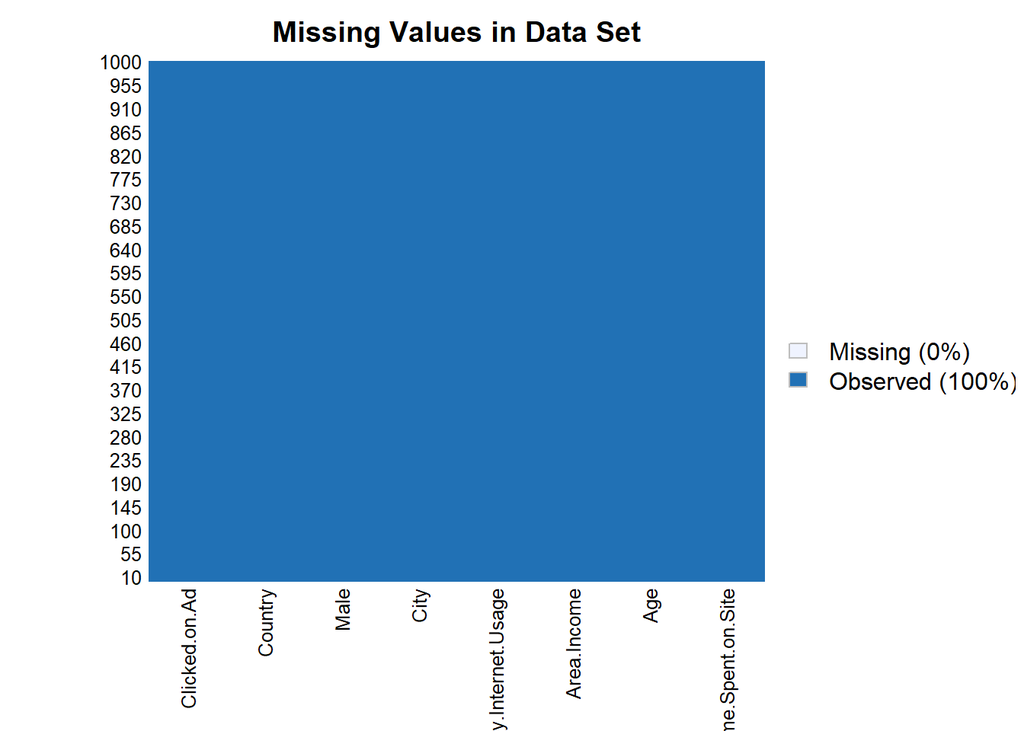

```r
library(Amelia)
missmap(advertising,main="Missing Values in Data Set")
```

## Tibbles

A tibble is a special kind of data.frame used by dplyr and other packages of the tidyverse. Tidyverse is a set of packages for data science that work in harmony because they share common data representations and API design. When a data.frame is turned into a tibble its class will change.

```r
class(advertising)
```

```
## [1] "data.table" "data.frame"
```

```r
advertising <- tbl_df(advertising)
class(advertising)
```

```
## [1] "tbl_df"     "tbl"        "data.frame"
```

## Data Overview

```
## Rows: 1,000
## Columns: 8
## $ Daily.Time.Spent.on.Site <dbl> 68.95, 80.23, 69.47, 74.15, 68.37, 59.99, ...
## $ Age                      <int> 35, 31, 26, 29, 35, 23, 33, 48, 30, 20, 49...
## $ Area.Income              <dbl> 61833.90, 68441.85, 59785.94, 54806.18, 73...
## $ Daily.Internet.Usage     <dbl> 256.09, 193.77, 236.50, 245.89, 225.58, 22...
## $ City                     <chr> "Wrightburgh", "West Jodi", "Davidton", "W...
## $ Male                     <int> 0, 1, 0, 1, 0, 1, 0, 1, 1, 1, 0, 1, 1, 0, ...
## $ Country                  <chr> "Tunisia", "Nauru", "San Marino", "Italy",...
## $ Clicked.on.Ad            <int> 0, 0, 0, 0, 0, 0, 0, 1, 0, 0, 1, 0, 1, 0, ...
```

## Data preview

```
## # A tibble: 6 x 8
##   Daily.Time.Spen~   Age Area.Income Daily.Internet.~ City   Male Country
##              <dbl> <int>       <dbl>            <dbl> <chr> <int> <chr>
## 1             69.0    35      61834.             256. Wrig~     0 Tunisia
## 2             80.2    31      68442.             194. West~     1 Nauru
## 3             69.5    26      59786.             236. Davi~     0 San Ma~
## 4             74.2    29      54806.             246. West~     1 Italy
## 5             68.4    35      73890.             226. Sout~     0 Iceland
## 6             60.0    23      59762.             227. Jami~     1 Norway
## # ... with 1 more variable: Clicked.on.Ad <int>
```

# Univariate analysis of a continuous variables

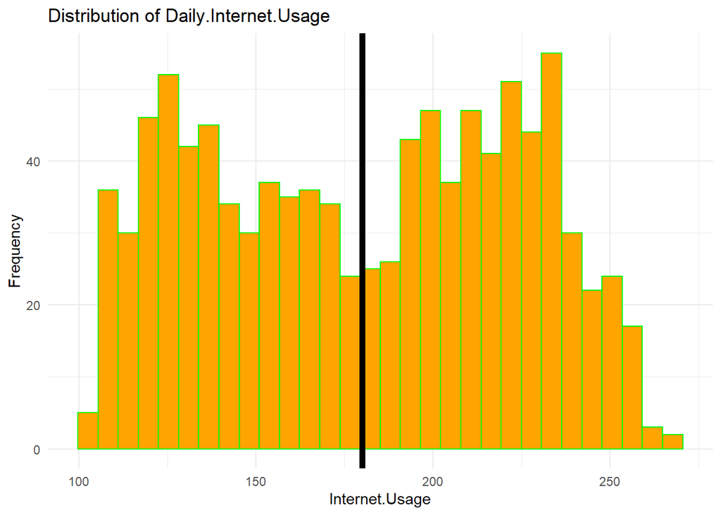

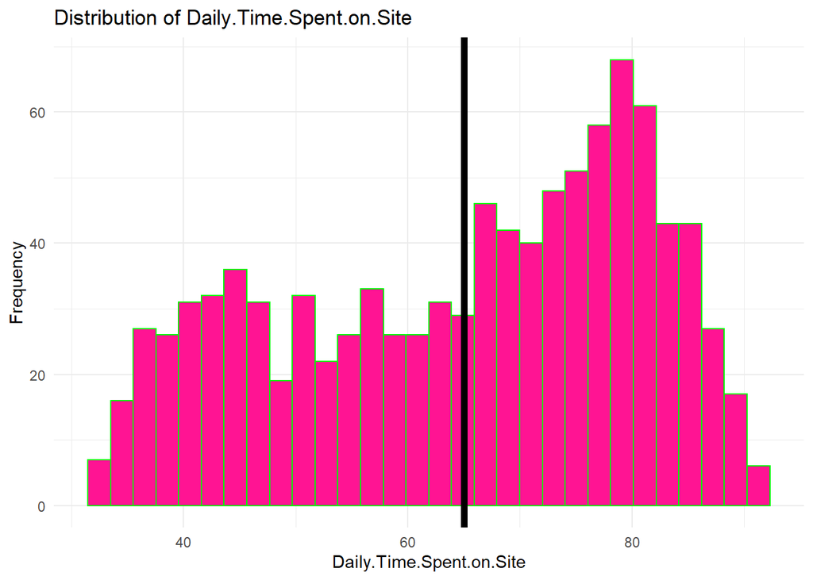

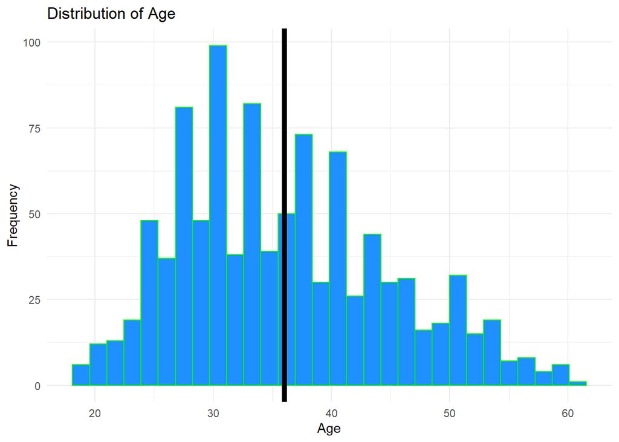

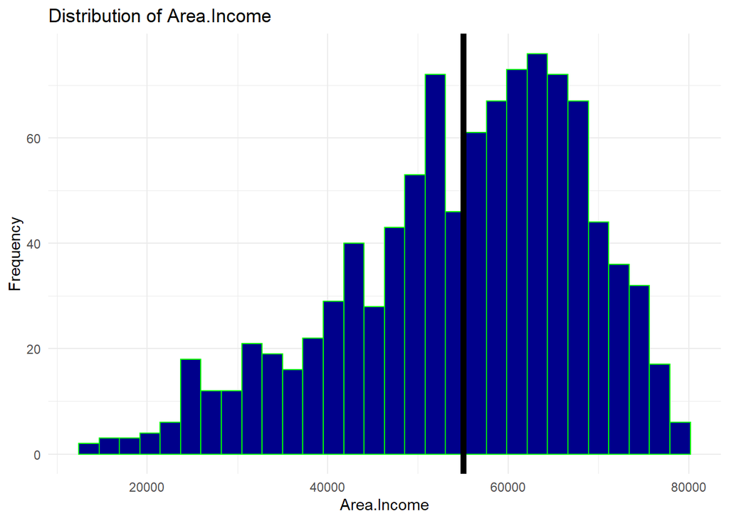

# Bivariate analysis of a continuous variable with respect to a categorical variable

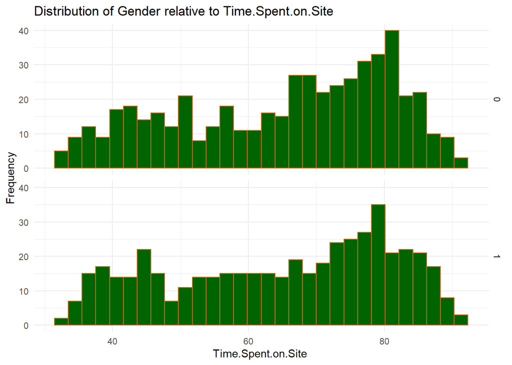

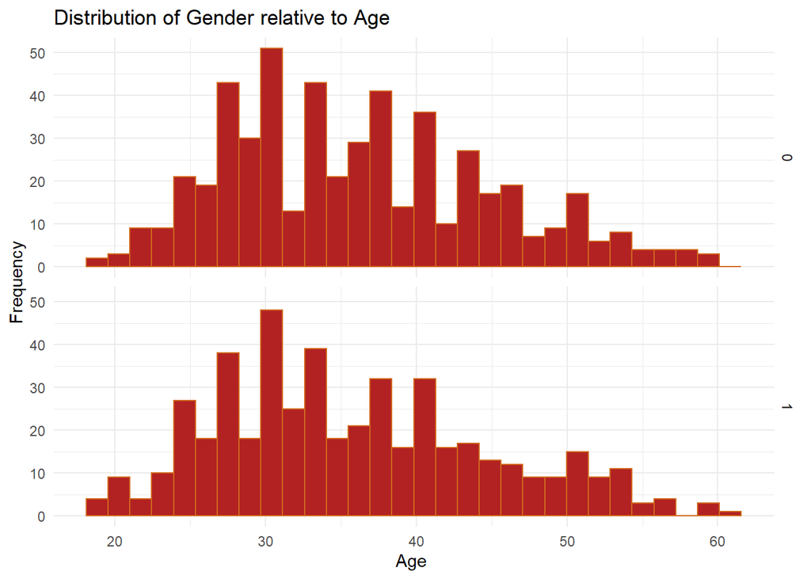

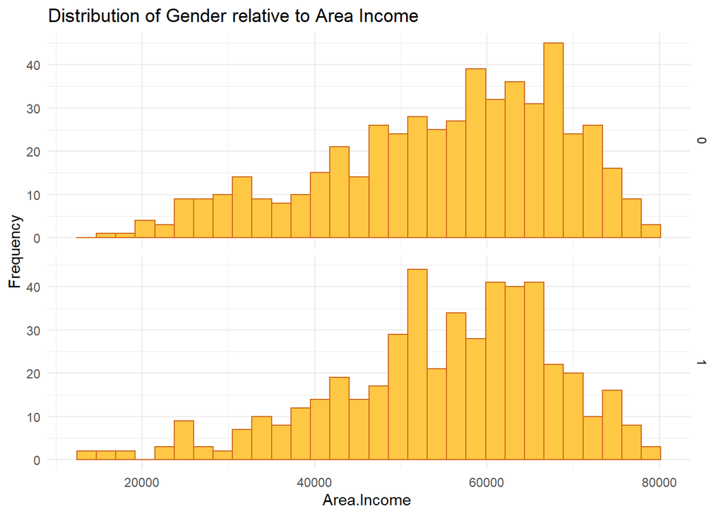

# Bivariate analysis of a continuous variable with respect to another continuous variable

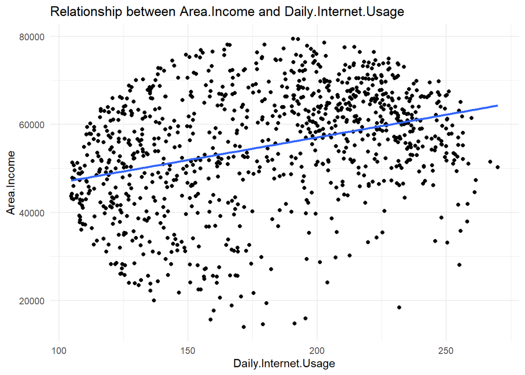

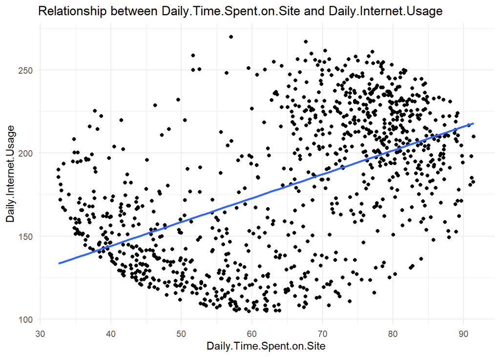

# Correlation Matrix for the advertising dataset

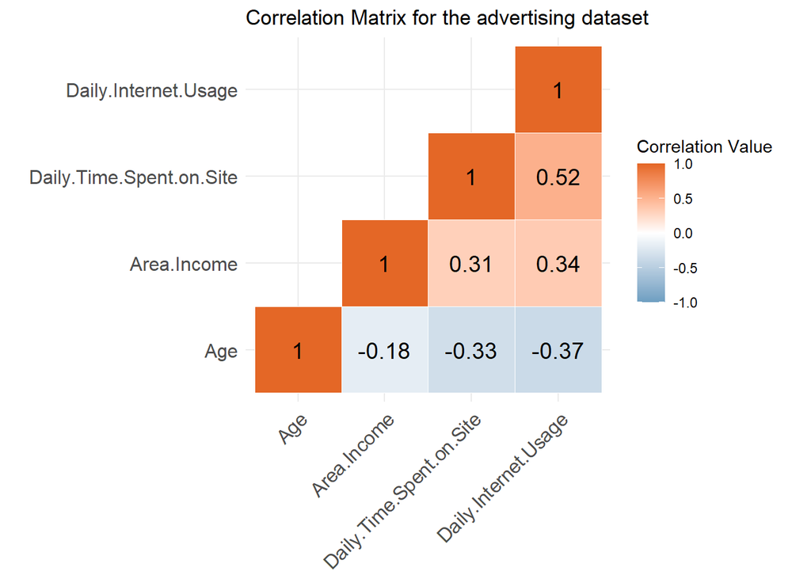

# ADVERTISMENT CLICK PREDICTION

```
## [1] 800   8
```

```
## [1] 200   8
```

```
##                                       Estimate           Std. Error
## (Intercept)              27.305100885827563673 3.05379157511344e+00
## Daily.Time.Spent.on.Site -0.199880144429769535 2.35673387205557e-02
## Age                       0.173651423497261981 2.81020896121447e-02
## Area.Income              -0.000145895799332851 2.16918987301115e-05
## Daily.Internet.Usage     -0.058756558947065468 6.92648417983533e-03
##                                    z value             Pr(>|z|)
## (Intercept)               8.94137671619362 3.84351722531505e-19
## Daily.Time.Spent.on.Site -8.48123527224699 2.22815540291544e-17
## Age                       6.17930644638669 6.43838145138161e-10
## Area.Income              -6.72581967803153 1.74606691527932e-11
## Daily.Internet.Usage     -8.48288358444823 2.19680431268135e-17
```

[figure not shown]

## Feature importance and Logistic Regression

[output not shown]

```
## [1] "Logistic Regression Confusion/Clarity Matrix)"
```

[output not shown]

```
## [1] "Logistic Regression Accuracy:  97.1098265895954"
```

Variable Importance:

|  | Overall | varnames | var_categ |
| --- | --- | --- | --- |
| Daily.Time.Spent.on.Site | 8.379334095222884 | Daily.Time.Spent.on.Site | Location |
| Age | 6.527516885189965 | Age | Location |
| Area.Income | 6.724826176192777 | Area.Income | Location |
| Daily.Internet.Usage | 8.633131371671141 | Daily.Internet.Usage | Location |
| Male | 0.582364607079277 | Male | Location |
| continent3 | 0.227296062920125 | continent3 | Location |
| continent4 | 0.098716143074804 | continent4 | Location |
| continent5 | 1.117696233696151 | continent5 | Location |

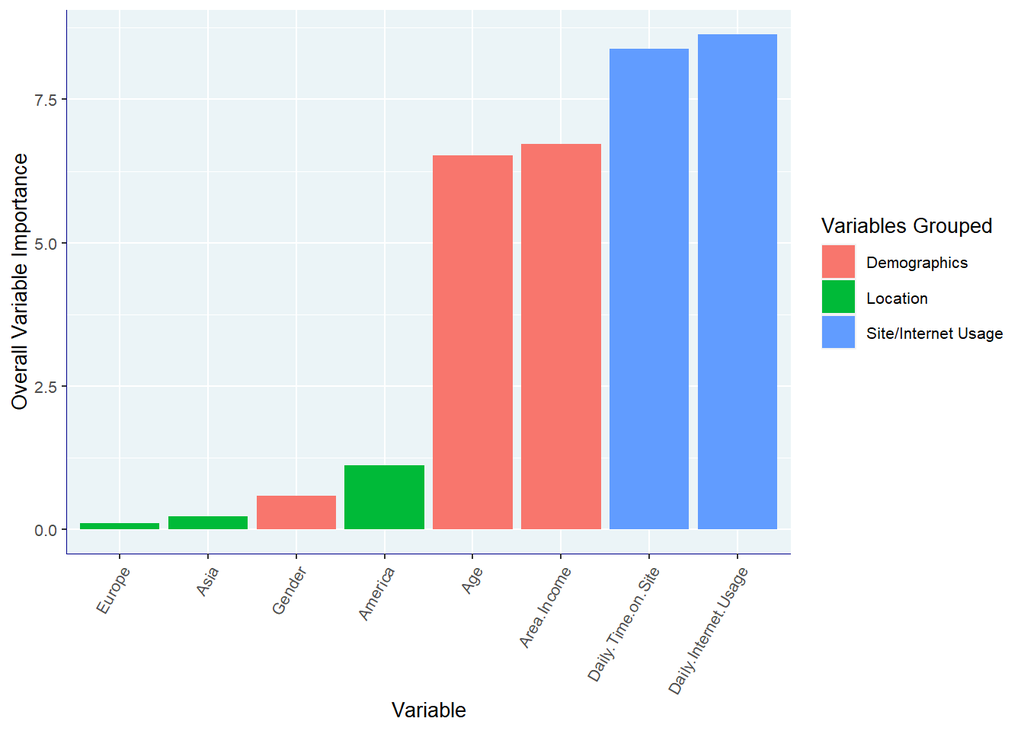